# Tvyal Newsletter

2025-03-11

*English summary below.*

## 🔢🕵️‍♀️🕳️️ [Շքեղ թվերի ետևում․ Հայաստանի տնտեսական աճի ստվերը](https://www.tvyal.com/newsletter/2025/2025_03_11)

Հայաստանի տնտեսությունն այսօր հայտնվել է ճակատագրական խաչմերուկում։ Վերջին վիճակագրական տվյալները բացահայտում են անհանգստացնող պատկեր՝ վերջին շրջանում այդքան գովաբանված տնտեսական վերելքը իրականում հիմնված է եղել անկայուն հիմքերի վրա։ Երբ խորությամբ ուսումնասիրում ենք փաստերը, պարզ է դառնում, որ տնտեսական աճի շքեղ թվերի ետևում թաքնված են լուրջ կառուցվածքային խնդիրներ։

### ՀՆԱ աճը․ Աճի անկայուն հիմքերը

#### Բարգավաճման պատրանքը

Հայաստանի տնտեսական աճի պաշտոնական ցուցանիշների վերլուծությունը հարցեր է առաջացնում երկրի տնտեսության իրական վիճակի մասին։ Պաշտոնական վիճակագրության ետևում թաքնված են մտահոգիչ միտումներ, որոնք պահանջում են վերաիմաստավորել երկրի տնտեսական կենսունակության մասին ընդունված պատկերացումները։

Գծապատկեր 1.

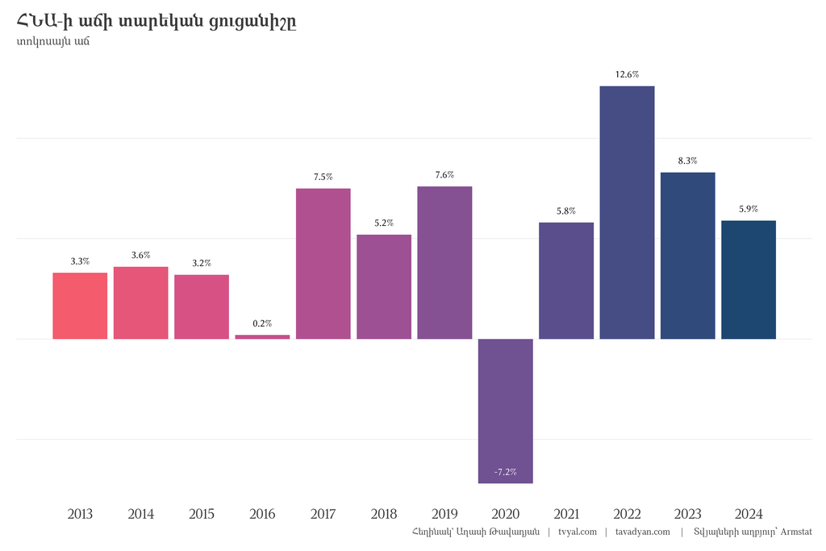

Առաջին գծապատկերն արտացոլում է Հայաստանի տնտեսական զարգացման անկայուն ընթացքը։ Երկարաժամկետ միջին աճի 4.5% ցուցանիշի համեմատ՝ վերջին տարիներին նկատվել են զգալի տատանումներ։ Հատկանշական է, որ 2022 թվականի տպավորիչ 12.6% աճին հաջորդել է նվազման տեմպ՝ 2023 թվականին հասնելով 8.3%-ի, իսկ 2024 թվականին՝ ընդամենը 5.9%-ի: Այս նվազող միտումը վկայում է տնտեսության խնդիրների մասին: Ավելին, այս աճի գրեթե կեսը պայմանավորված է եղել առևտրի և ֆինանսական ծառայությունների ոլորտներով, որոնք իրենց հերթին ծանր կախվածություն ունեն արտաքին գործոններից, հատկապես՝ ռուսական կապիտալի ներհոսքից և ռուսական բիզնեսներից։

#### Աճի պատրանքի իրական պատկերը

Պաշտոնական վիճակագրությունը բացահայտում է աճի անկայուն պատկեր, որը հուշում է հայաստանյան տնտեսության խորքային թերությունները․

1. 2024թ․ աճի տեմպերը սրընթաց նվազել են։ Չորրորդ եռամսյակում տնտեսական աճը կազմել է ընդամենը 3.7%, մինչդեռ առաջին եռամսյակում այն 7.9% էր։
2. 2022-2024թթ․ ընթացքում աճի տեմպերը հետևողականորեն անկում են ապրել՝ 12.6%-ից (2022թ.) իջնելով 8.3%-ի (2023թ.) և հասնելով 5.9%-ի (2024թ.)։
3. Տեղեկատվական տեխնոլոգիաների ոլորտը, որը նախկինում տնտեսական աճի առաջամարտիկն էր, զգալի անկում է գրանցել 2023թ․ չորրորդ եռամսյակում (-2.8%), իսկ 2024թ․ երկրորդ եռամսյակում ցուցաբերել է աննշան աճ (4.5%):

Այս ցուցանիշները լուռ վկաներն են Հայաստանի տնտեսության առջև ծառացած կառուցվածքային խնդիրների մասին։ Մինչև վերջերս առաջին հայացքից դինամիկ աճ ցուցաբերող տնտեսությունն այժմ դրսևորում է լճացման նշաններ՝ հատկապես բարձր ավելացված արժեք ստեղծող ճյուղերում:

Գծապատկեր 2.

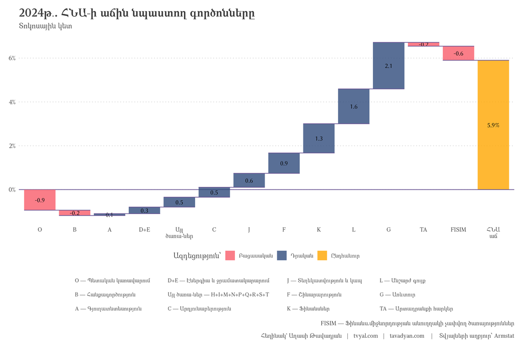

Երկրորդ գծապատկերում ներկայացված են 2024 թվականի ՀՆԱ աճին նպաստող բաղադրիչները: Վերլուծությունը բացահայտում է տագնապալի պատկեր․ տնտեսական աճը խիստ անհամաչափ է և հիմնականում կենտրոնացած է ծառայությունների ոլորտում։ 5.9% աճի ապահովման հիմնական բաղադրիչներն են.

1. Առևտուրը (G)՝ 2.1 տոկոսային կետ,
2. Անշարժ գույքի գործունեությունը (L)՝ 1.6 տոկոսային կետ,
3. Ֆինանսական ծառայությունները (K)՝ 1.3 տոկոսային կետ,
4. Շինարարությունը (F)՝ 0.9 տոկոսային կետ,
5. Տեղեկատվություն և կապը (J)՝ 0.6 տոկոսային կետ։

Անհանգստացնող է, որ արտադրող և բարձր ավելացված արժեք ստեղծող ճյուղերը չեն հանդիսանում աճի շարժիչ ուժեր։ Ավելին, մի շարք կարևորագույն ոլորտներ բացասական ազդեցություն են թողել ընդհանուր աճի վրա.

1. Պետական կառավարում (O)՝ -0.9 տոկոսային կետ,
2. Հանքարդյունաբերություն (B)՝ -0.2 տոկոսային կետ,
3. ՖՄԱՉԾ (Ֆինանսական միջնորդության անուղղակիորեն չափվող ծառայություններ)՝ -0.6 տոկոսային կետ։

Մեր իրականացրած վերլուծությունը ցույց է տալիս, որ ոսկու վերաարտահանումից ստացված ավելացված արժեքը վճռորոշ դեր է խաղացել ՀՆԱ-ի աճի գործում։ Մեր [նախկին հետազոտության մեջ նշել ենք, որ ոսկու վերաարտահանման «արդյունաբերությունը» մոտ 4 տոկոսային կետի ներդրում է ունեցել, առևտուրը՝ 3 տոկոսային կետ, ֆինանսական ծառայությունները՝ 1.1 տոկոսային կետ, մինչդեռ տնտեսության մնացած ճյուղերը միասին արձանագրել են -0.1% անկում։](https://www.aravot.am/2024/08/10/1437252/) [Ինչպես արտացոլված է մեր նախորդ վերլուծության մեջ՝ այս ոսկե վերաարտահանման գործունեությունը կազմում է արտահանման մոտ 61.4%-ը](https://www.tvyal.com/newsletter/2025/2025_02_25) և հանդիսանում է իրական տնտեսական անկումը քողարկող հիմնական գործոն։

#### «Թանկարժեք» էֆֆեկտ․ Ոսկու վերաարտահանման քողը

Այս տնտեսավիճակագրական դրամայի առանցքում ոսկու վերաարտահանման երևույթն է, որը թափ է ստացել 2023թ․ նոյեմբերից և շարունակվել է մինչև 2024թ․ մայիս։ Այս գործոնը արհեստական կենսունակություն է հաղորդել Հայաստանի աճի ցուցանիշներին։ [Սակայն փաստերն ցույց են տալիս, որ սա անցողիկ բնույթ ունի և ամուր հիմքեր չունի](https://www.tvyal.com/newsletter/2025/2025_02_25):

### Տնտեսության ճյուղերը և դրանց ներդրումը

#### Ճյուղերի կատարողականի ակնարկ

Գծապատկեր 3.

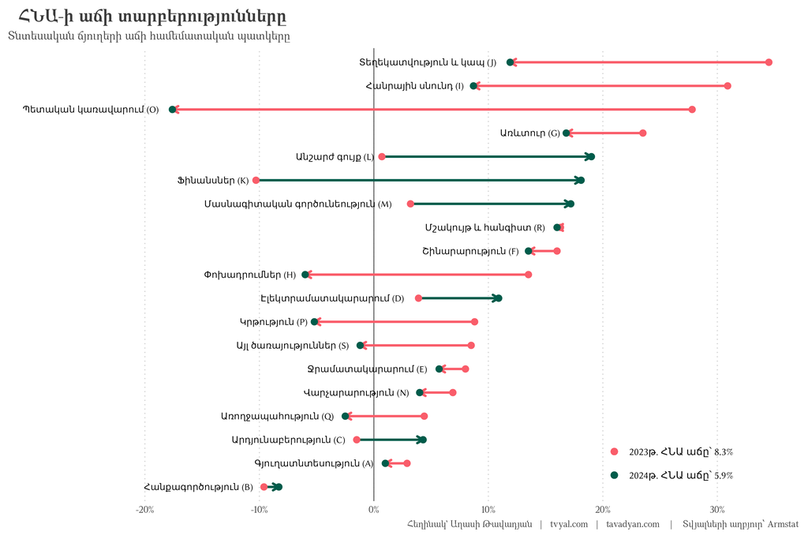

Երրորդ գծապատկերը ցուցադրում է աճի տեմպերի էական տարբերություններ տարբեր ճյուղերի միջև, ինչը վկայում է, որ տնտեսական աճը ոչ միայն անհավասարաչափ է բաշխված, այլև կայուն չէ։

Հիմնական եզրահանգումներ․

1. ՏՏ ոլորտը (J), որը 2023 թվականին հանդիսանում էր աճի առաջատար շարժիչներից մեկը՝ գրանցելով 34.5% տարեկան աճ, այժմ հայտնվել է դժվարությունների մեջ։ 2024թ․ այն արձանագրել է 11.9% աճ։
2. Այլ ոլորտների աճը նույնպես դանդաղում է գրանցել։
3. Առևտուրը, որը հանդիսացել է 2024թ․ տնտեսական աճի հիմնական շարժիչ ուժը, 2024թ․ գրանցել է 16.8% աճ, համեմատած 2023թ․ 23.5% տնտեսական աճի հետ։
4. Նկատելի աճել են անշարժ գույքի հետ կապված գործարքները և ֆինանսական ոլորտը։

### Տնտեսական աճի կայունությունը

Գծապատկեր 4.

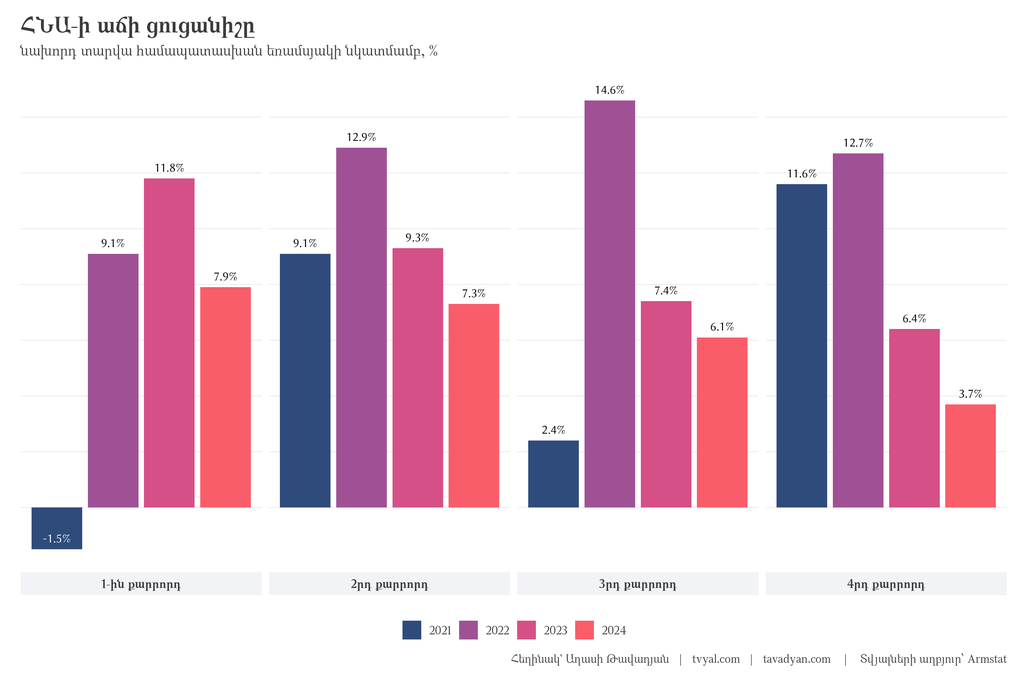

4-րդ գծապատկերը պատկերում է ՀՆԱ աճը ըստ եռամսյակների, որտեղ յուրաքանչյուր եռամսյակ ներկայացնում է աճը նախորդ տարվա նույն եռամսյակի համեմատ։ Այստեղ մտահոգիչն այն է, որ 2024թ․ վերջին եռամսյակը համեմատած 2023թ․ վերջին եռամսյակի հետ գրանցվել է ընդամենը 3.7% աճ՝ համեմատած տարեկան 5.9% ցուցանիշի հետ։ Ընդհանուր եռամսյակային ցուցանիշների կտրվածքով տնտեսական աճի դանդաղումը ավելի տեսանելի է։

#### Աճի շարժիչ ուժերի վերլուծություն

Գծապատկեր 5.

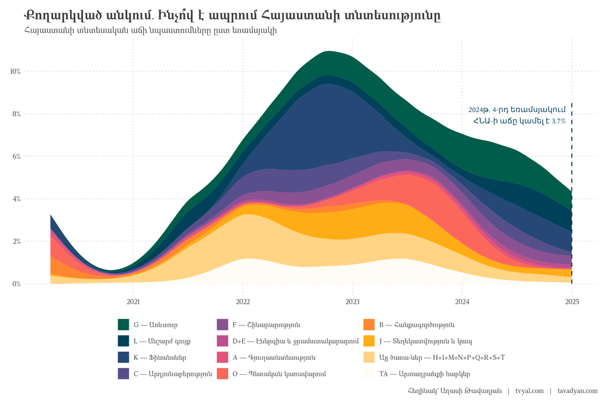

Գծապատկեր 5-ը ցույց է տալիս Հայաստանի տնտեսական աճին նպաստող գործոնները ըստ եռամսյակների։ Մի քանի էական դիտարկումներ են ընդգծման արժանի․

1. Երկարաժամկետ միջին աճ․ Հայաստանի երկարաժամկետ միջին տնտեսական աճի տեմպը մոտ 4.5% է։ Ցանկացած համակարգ ձգտում է վերադառնալ իր երկարաժամկետ միջինին, եթե չկան տվյալ համակարգում որակական փոփոխություններ, որոնք կարող են ապահովել կայուն, երկարաժամկետ ավելացված արժեքի ստեղծում։
2. Հետհամաճարագային վերականգնում․ 2020թ․ COVID-19 համավարակից և 44-օրյա պատերազմից հետո տնտեսությունը ցուցաբերեց վերականգնման նշաններ։ Տնտեսության հիմնական ճյուղերը ապահովեցին տնտեսական աճի մոտ 4.5%-ը։
3. ՏՏ ոլորտի ներդրում․ ՏՏ ոլորտը (J) ապահովեց աճի մոտ 1-2.5 տոկոսային կետը, հիմնականում Ռուսաստանից վերաբնակեցված ՏՏ մասնագետների ներհոսքի շնորհիվ։ Սակայն այս ոլորտը վերջին երեք եռամսյակում խորը անկում է ապրում։
4. Ֆինանսական ծառայություններ և առևտուր․ 2022 թվականի սկզբից ՀՆԱ հիմնական հավելաճն ապահովվել է ֆինանսական ծառայությունների (K) և առևտրի կողմից (G)։ Հարկ է արձանագրել, որ Ռուսաստանից մեծ ծավալով կապիտալի ներհոսքի արդյունքում՝ բանկային համակարգի զուտ շահույթը 2022 թվականին եռապատկվեց ([Կարդացեք ավելին՝ 💸🔚🏦 Կապիտալի արտահոսք](https://www.tvyal.com/newsletter/2024/2024_03_01))։
5. Ընդհանուր առմամբ միայն ՏՏ և բանկային ոլորտը արտաքին ազդակի հիման վրա ապահովեցին 2022թ․ 12.6% աճի գրեթե կեսը։
6. Գծապատկերից երևում է, որ 2023թ․ կեսից ՏՏ ոլորտը, հանքարդյունաբերությունը, պետական կառավարումը, ինչպես նաև այլ ծառայությունները չեն ապահովում նույն աճի տեմպը, ինչ 2022 թվականին։
7. Նկատվում է անշարժ գույքի և բանկային համակարգի զգալի նպաստումը վերջին տնտեսական աճի մեջ։

#### Կախվածությունը ժամանակավոր և արհեստական գործոններից

Տվյալները հստակորեն վկայում են, որ Հայաստանի տնտեսական աճը մեծապես պայմանավորված է եղել արտաքին գործոններով․

1. 2022 թվականին Ռուսաստանից եկավ զգալի կապիտալի ներհոսք։
2. 2023 թվականի նոյեմբերից սկսած խոշորածավալ ոսկու վերաարտահանումը արհեստականորեն բարձրացրեց աճի ցուցանիշները (ավելին․ [🇷🇺💰🇦🇲 Հայաստան` ռուսական ոսկու հանգրվան](https://www.tvyal.com/newsletter/2024/2024_07_05)):
3. Աճը հիմնականում ապահովվում է առևտրի, անշարժ գույքի և ֆինանսական ծառայությունների կողմից, որոնք խիստ կախվածություն ունեն արտաքին գործոններից (ավելին․ [🌅🏖🌄 Սահմանից այն կողմ․ Հայաստանի տուրիստական աճը և հնարավոր անկումը](https://www.tvyal.com/newsletter/2024/2024_06_17)):

Այս գործոնները, թեև կարճաժամկետ խթան են հանդիսանում, չեն կարող դիտարկվել որպես կայուն, երկարաժամկետ տնտեսական աճի երաշխավորներ։ Նման պայմաններում տնտեսական աճը անխուսափելիորեն ձգտելու է իր երկարաժամկետ միջին ցուցանիշին։

### Հարկաբյուջետային հետևանքները

Տնտեսական աճի կայունության հետ կապված խնդիրները անմիջական ազդեցություն են թողնում Հայաստանի հարկաբյուջետային իրավիճակի վրա։

Ներկայումս առկա է հարկային եկամուտների զգալի մոտ 8% թերհավաքագրում։ Այս բացը հանգեցնում է բյուջետային ծախսերի հնարավոր կրճատման քննարկումների ([Կարդացեք ավելին՝ 🧮⏳🎲 Հայաստանը հարկում է ժամանակը․ Խաղ տնտեսական աճի հետ](https://www.tvyal.com/newsletter/2024/2024_08_02))։

### Եզրակացություն

ՀՆԱ-ի վերջին տվյալները և ճյուղային վերլուծությունները մտահոգիչ պատկեր են ուրվագծում Հայաստանի տնտեսական ապագայի համար։ Արտաքին գործոններից Հայաստանի տնտեսության խոր կախվածությունը և ոսկու վերաարտահանման նման գործունեությունից ստացվող ժամանակավոր խթանները ցույց են տալիս, որ առանց էական կառուցվածքային բարեփոխումների, բարձր աճի տեմպերի պահպանումը անհնարին է դառնալու։

Ներկայիս պայմաններում, ՀՆԱ աճի մեր երկարաժամկետ կանխատեսումները այս պահին հուսադրող չեն։ Առանց կայուն, երկարաժամկետ ավելացված արժեքի աճի կենսունակ հիմքի, Հայաստանը կարող է շարունակել տնտեսական պատրանքների հետապնդումը՝ իրական բարգավաճման կառուցման փոխարեն։ Առաջիկա ամիսները և տարիները վճռորոշ կլինեն՝ որոշելու, թե արդյոք երկիրը կկարողանա ուղղություն վերցնել դեպի ավելի կայուն տնտեսական ռազմավարություններ, թե կշարունակի հիմնվել ոչ կայուն և ժամանակավոր աճի գործոնների վրա։

Եթե հնարավոր է, խնդրում եմ այս նյութը ուղարկել նաև այն մարդկանց, ում այն կարծում եք կարող է հետաքրքրել:

**ԱՅՍ ՀՈԴՎԱԾԻ ՀՂՈՒՄԸ**

*Թավադյան, Աղ․Ա․ (2025)․ Շքեղ թվերի ետևում․ Հայաստանի տնտեսական աճի ստվերը [Tvyal.com platform], 11-03-2025․ https://www.tvyal.com/newsletter/2025/2025_03_11*

**Արգելվում է այս հարթակի նյութերը արտատպել առանց հղում կատարելու։**

* Այս և մեր բոլոր այլ վերլուծությունների տվյալները վերցված են պաշտոնական աղբյուրներից։ Հաշվարկները ամբողջությամբ հասանելի են github-ում, դրանք կարելի է ստուգել` այցելելով [github-ի](https://github.com/tavad/tvyal_newsletter/blob/main/2025/) մեր էջը, որտեղ տրված են տվյալները, հաշվարկների և գծապատկերների կոդը։

# ՀԱՄԱԳՈՐԾԱԿՑՈՒԹՅՈՒՆ

## Եթե ուզում եք AI գործիքներով ձեր տվյալներից օգուտ քաղել` ԴԻՄԵՔ ՄԵԶ

### Մենք առաջարկում ենք

- Extensive databases for finding both international and local leads
- Exclusive reports on the Future of the Armenian Economy
- Work and browser automation to streamline operations and reduce staffing needs
- AI models for forecasting growth and optimizing various aspects of your business
- Advanced dashboarding and BI solutions
- Algorithmic trading

### Let’s Put Your Data to Work!

### ՄԻԱՑԵՔ ՄԵՐ ԹԻՄԻՆ

## English Summary

### 🔢🕵️‍♀️🕳️️ Behind the Impressive Numbers: Shadows in Armenia’s Economic Growth

**The Illusion of Armenia’s Economic Growth**

Armenia’s economy is at a critical juncture, with recent GDP growth revisions revealing a concerning reality. The economic boom that was widely celebrated in recent times was largely built on unstable factors. A detailed analysis of the data shows that despite apparent growth, the economy is facing serious challenges. The GDP growth figures have been revised downwards by up to 2.6 percentage points, forcing a reevaluation of the country’s economic health.

The economic growth has been heavily reliant on external factors, including significant capital inflow from Russia in 2022 and large-scale gold re-exports starting from November 2023. The IT sector, once a driving force of growth, has experienced a significant decline. The growth is mainly supported by trade, real estate, and financial services, all of which are dependent on external factors. These elements, while providing short-term stimulus, do not represent sustainable, long-term economic growth drivers. Without significant structural changes, maintaining high growth rates will be challenging, and there’s a risk of increasing public debt and potential fiscal instability in the coming years.

Հարգանքներով,  
Աղասի Թավադյան  
11.03.2025  
[tvyal.com](https://www.tvyal.com/)  
[tavadyan.com](https://www.tavadyan.com/)

[Was this email forwarded to you? Subscribe here.](https://www.tvyal.com/subscribe)

[Բաժանորդագրվեք](https://www.tvyal.com/subscribe)

**Ուշադրություն. Ձեր էլ.փոստը մեյլլիսթի մեջ է, որի միջոցով ես կիսվում եմ շաբաթական նյութեր, որոնք հիմնականում ներկայացնում են Հայաստանի տնտեսությունը: Նյութերը ներառում են գծապատկերներ, [տվյալների բազաներ](https://github.com/tavad/tvyal_newsletter), տեսանյութեր, հոդվածներ, [առցանց վահանակներ](https://www.tvyal.com/projects), տնտեսական գործիքներ, կանխատեսումներ և հաշվետվություններ: Եթե ցանկանում եք չեղարկել բաժանորդագրությունը, խնդրում եմ տեղեկացրեք ինձ, և ես կհեռացնեմ ձեր էլ. փոստը ցուցակից: Գրեք նաև եթե ունեք մենկնաբանություններ:**

**Important! Your email is part of the mailing list where I share weekly materials primarily focused on the Armenian economy. These materials encompass charts, [databases](https://github.com/tavad/tvyal_newsletter), videos, articles, [online dashboards](https://www.tvyal.com/projects), economic tools, forecasts, and reports. If you wish to unsubscribe, please let me know, and I will remove your email from the list. Please share your comments as well․**